# COVID 19 Visualization

Tanvi Hasija

2023-01-23

### Dataset

We will begin by using COVID-19 data from Our World in Data, and later, to that, we will add more data from World Health Organization.

1. Download [this](https://covid.ourworldindata.org/data/owid-covid-data.csv) CSV from Our World in Data.
2. Download [this](https://covid19.who.int/WHO-COVID-19-global-data.csv) CSV from World Health Organization.

### R Packages

#### Download the required packages.

Note: Run these commands manually in the R console

```
install.packages("tidyverse")
install.packages("ggplot2")
install.packages("ggmap")
```

#### Attach these packages

```r
library(tidyverse)
```

```r
library(ggplot2)
library(ggmap)
library(scales)
```

### Phase 1: Vizualing the first dataset

#### Capturing and cleaning the data

##### Capture the World Map

```r
world_map <- map_data('world')
head(world_map)
```

```
##        long      lat group order region subregion
## 1 -69.89912 12.45200     1     1  Aruba      <NA>
## 2 -69.89571 12.42300     1     2  Aruba      <NA>
## 3 -69.94219 12.43853     1     3  Aruba      <NA>
## 4 -70.00415 12.50049     1     4  Aruba      <NA>
## 5 -70.06612 12.54697     1     5  Aruba      <NA>
## 6 -70.05088 12.59707     1     6  Aruba      <NA>
```

##### Read COVID-19 CSV from OurWorldInData and understand its structure

```r
all_owid_cases <- read.csv('owid-covid-data.csv', header=TRUE)
names(all_owid_cases)
```

```
##  [1] "iso_code"
##  [2] "continent"
##  [3] "location"
##  [4] "date"
##  [5] "total_cases"
##  [6] "new_cases"
##  [7] "new_cases_smoothed"
##  [8] "total_deaths"
##  [9] "new_deaths"
## [10] "new_deaths_smoothed"
## [11] "total_cases_per_million"
## [12] "new_cases_per_million"
## [13] "new_cases_smoothed_per_million"
## [14] "total_deaths_per_million"
## [15] "new_deaths_per_million"
```

[output cut: 52 more lines]

##### Group the number of cases country-wise and make sure to filter out N/A values

```r
country_wise_owid_cases <- all_owid_cases %>%
  group_by(location) %>%
  summarise(count=sum(new_cases, na.rm=TRUE)) %>%
  arrange(desc(count))
head(country_wise_owid_cases)
```

```
## # A tibble: 6 × 2
##   location                count
##   <chr>                   <dbl>
## 1 World               667042226
## 2 High income         425184557
## 3 Europe              245936024
## 4 Asia                206734319
## 5 European Union      183258425
## 6 Upper middle income 143024408
```

##### Filter out globally categorized data as we don’t need it for our analysis

```r
country_wise_owid_cases <- country_wise_owid_cases[ !(country_wise_owid_cases$location %in% list("World", "High income", "Europe", "Asia", "European Union", "Upper middle income", "North America", "Lower middle income", "South America", "Low income", "Africa", "International")), ]
head(country_wise_owid_cases)
```

```
## # A tibble: 6 × 2
##   location          count
##   <chr>             <dbl>
## 1 United States 102003089
## 2 India          44685083
## 3 France         39970300
## 4 Germany        37668384
## 5 Brazil         36612555
## 6 Japan          32003018
```

##### Check for the differences in country names in the COVID data and the world map data (for eg “United States” vs “USA”)

```r
setdiff(world_map$region, country_wise_owid_cases$location)
```

```
##  [1] "American Samoa"                      "Antarctica"
##  [3] "French Southern and Antarctic Lands" "Antigua"
##  [5] "Barbuda"                             "Saint Barthelemy"
##  [7] "Ivory Coast"                         "Democratic Republic of the Congo"
##  [9] "Republic of Congo"                   "Czech Republic"
## [11] "Canary Islands"                      "Reunion"
## [13] "Mayotte"                             "French Guiana"
## [15] "Martinique"                          "Guadeloupe"
## [17] "Faroe Islands"                       "Micronesia"
## [19] "UK"                                  "Heard Island"
## [21] "Cocos Islands"                       "Christmas Island"
## [23] "Chagos Archipelago"                  "Siachen Glacier"
## [25] "Nevis"                               "Saint Kitts"
## [27] "Saint Martin"                        "Norfolk Island"
## [29] "Bonaire"                             "Sint Eustatius"
## [31] "Saba"                                "Pitcairn Islands"
## [33] "Madeira Islands"                     "Azores"
## [35] "South Sandwich Islands"              "South Georgia"
## [37] "Ascension Island"                    "Swaziland"
## [39] "Sint Maarten"                        "Timor-Leste"
## [41] "Trinidad"                            "Tobago"
## [43] "USA"                                 "Grenadines"
## [45] "Saint Vincent"                       "Virgin Islands"
```

##### Fix the anomallies

```r
country_wise_owid_cases$location[country_wise_owid_cases$location=='Congo'] = "Republic of Congo"
country_wise_owid_cases$location[country_wise_owid_cases$location=="Cote d'Ivoire"] = "Ivory Coast"
country_wise_owid_cases$location[country_wise_owid_cases$location=="Czechia"] = "Czech Republic"
country_wise_owid_cases$location[country_wise_owid_cases$location=="Democratic Republic of Congo"] = "Democratic Republic of the Congo"
country_wise_owid_cases$location[country_wise_owid_cases$location=="Eswatini"] = "Swaziland"
country_wise_owid_cases$location[country_wise_owid_cases$location=="Faeroe Islands"] = "Faroe Islands"
country_wise_owid_cases$location[country_wise_owid_cases$location=="Micronesia (country)"] = "Micronesia"
country_wise_owid_cases$location[country_wise_owid_cases$location=="Pitcairn"] = "Pitcairn Islands"
country_wise_owid_cases$location[country_wise_owid_cases$location=="Sint Maarten (Dutch part)"] = "Sint Maarten"
country_wise_owid_cases$location[country_wise_owid_cases$location=="Timor"] = "Timor-Leste"
country_wise_owid_cases$location[country_wise_owid_cases$location=="United Kingdom"] = "UK"
country_wise_owid_cases$location[country_wise_owid_cases$location=="United States"] = "USA"
country_wise_owid_cases$location[country_wise_owid_cases$location=="United States Virgin Islands"] = "Virgin Islands"

temp_ct <- country_wise_owid_cases$count[country_wise_owid_cases$location=='Antigua and Barbuda']
country_wise_owid_cases$location[country_wise_owid_cases$location=='Antigua and Barbuda'] = "Antigua"
country_wise_owid_cases[nrow(country_wise_owid_cases) + 1,] = list("Barbuda", temp_ct)

temp_ct <- country_wise_owid_cases$count[country_wise_owid_cases$location=='Bonaire Sint Eustatius and Saba']
country_wise_owid_cases$location[country_wise_owid_cases$location=='Bonaire Sint Eustatius and Saba'] = "Bonaire"
country_wise_owid_cases[nrow(country_wise_owid_cases) + 1,] = list("Sint Eustatius", temp_ct)
country_wise_owid_cases[nrow(country_wise_owid_cases) + 1,] = list("Saba", temp_ct)

temp_ct <- country_wise_owid_cases$count[country_wise_owid_cases$location=='Saint Kitts and Nevis']
country_wise_owid_cases$location[country_wise_owid_cases$location=="Saint Kitts and Nevis"] = "Saint Kitts"
country_wise_owid_cases[nrow(country_wise_owid_cases) + 1,] = list("Nevis", temp_ct)

temp_ct <- country_wise_owid_cases$count[country_wise_owid_cases$location=='Saint Vincent and the Grenadines']
country_wise_owid_cases$location[country_wise_owid_cases$location=="Saint Vincent and the Grenadines"] = "Saint Vincent"
country_wise_owid_cases[nrow(country_wise_owid_cases) + 1,] = list("Grenadines", temp_ct)

temp_ct <- country_wise_owid_cases$count[country_wise_owid_cases$location=='Trinidad and Tobago']
country_wise_owid_cases$location[country_wise_owid_cases$location=="Trinidad and Tobago"] = "Trinidad"
country_wise_owid_cases[nrow(country_wise_owid_cases) + 1,] = list("Tobago", temp_ct)
```

##### Rename the column “location” to “region” for inner join to work

```r
colnames(country_wise_owid_cases) <- c("region", "count")
names(country_wise_owid_cases)
```

```
## [1] "region" "count"
```

##### Inner join the data

```r
data_owid <- inner_join(world_map, country_wise_owid_cases, by="region")
head(data_owid)
```

```
##        long      lat group order region subregion count
## 1 -69.89912 12.45200     1     1  Aruba      <NA> 44819
## 2 -69.89571 12.42300     1     2  Aruba      <NA> 44819
## 3 -69.94219 12.43853     1     3  Aruba      <NA> 44819
## 4 -70.00415 12.50049     1     4  Aruba      <NA> 44819
## 5 -70.06612 12.54697     1     5  Aruba      <NA> 44819
## 6 -70.05088 12.59707     1     6  Aruba      <NA> 44819
```

#### Plotting

##### Define a plain and aesthetics for plotting

```r
plain <- theme(
  axis.text = element_blank(),
  axis.line = element_blank(),
  axis.ticks = element_blank(),
  panel.border = element_blank(),
  panel.grid = element_blank(),
  axis.title = element_blank(),
  panel.background = element_rect(fill = "white"),
  plot.title = element_text(hjust = 0.5)
)
aesthetics <- scale_fill_distiller(palette="Spectral", label=number_format(scale=1e-6, suffix = "M"))
```

##### Plot

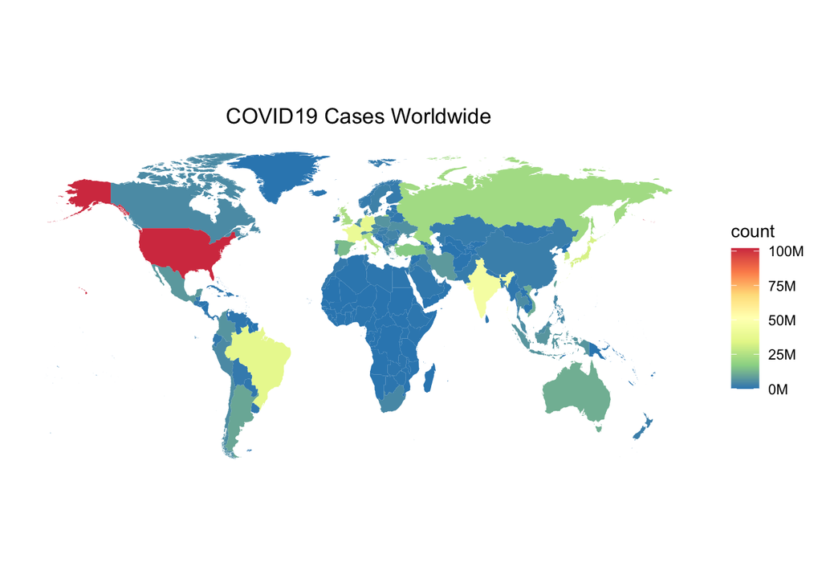

```r
world_plot_owid <- ggplot(data = data_owid, mapping = aes(x = long, y = lat, group = group)) +
  coord_fixed(1.3) +
  geom_polygon(aes(fill = count)) +
  ggtitle("COVID19 Cases Worldwide") +
  plain +
  aesthetics
world_plot_owid
```

### Phase 2: Adding more data to Phase 1 dataset and vizualizing again

#### Capturing and cleaning the data

##### Read COVID-19 CSV from WorldHealthOrganization and understand its structure

```r
all_who_cases <- read.csv('WHO-COVID-19-global-data.csv', header=TRUE)
names(all_who_cases)
```

```
## [1] "Date_reported"     "Country_code"      "Country"
## [4] "WHO_region"        "New_cases"         "Cumulative_cases"
## [7] "New_deaths"        "Cumulative_deaths"
```

##### Group the number of cases country-wise and make sure to filter out N/A values

```r
country_wise_who_cases <- all_who_cases %>%
  group_by(Country) %>%
  summarise(count=sum(New_cases, na.rm=TRUE)) %>%
  arrange(desc(count))
head(country_wise_who_cases)
```

```
## # A tibble: 6 × 2
##   Country                      count
##   <chr>                        <int>
## 1 United States of America 100651473
## 2 China                     98328848
## 3 India                     44682437
## 4 France                    38402957
## 5 Germany                   37728155
## 6 Brazil                    36768677
```

##### Check for the differences in country names in the new data and the world map data (for eg “United States” vs “USA”)

```r
setdiff(world_map$region, country_wise_who_cases$Country)
```

```
##  [1] "Antarctica"                          "French Southern and Antarctic Lands"
##  [3] "Antigua"                             "Barbuda"
##  [5] "Saint Barthelemy"                    "Bolivia"
##  [7] "Brunei"                              "Ivory Coast"
##  [9] "Republic of Congo"                   "Cape Verde"
## [11] "Curacao"                             "Czech Republic"
## [13] "Canary Islands"                      "Falkland Islands"
## [15] "Reunion"                             "Micronesia"
## [17] "UK"                                  "Heard Island"
## [19] "Cocos Islands"                       "Christmas Island"
## [21] "Chagos Archipelago"                  "Iran"
## [23] "Siachen Glacier"                     "Nevis"
## [25] "Saint Kitts"                         "South Korea"
## [27] "Kosovo"                              "Laos"
## [29] "Moldova"                             "Northern Mariana Islands"
## [31] "Norfolk Island"                      "North Korea"
## [33] "Madeira Islands"                     "Azores"
## [35] "Palestine"                           "Russia"
## [37] "Western Sahara"                      "South Sandwich Islands"
## [39] "South Georgia"                       "Saint Helena"
## [41] "Ascension Island"                    "Swaziland"
## [43] "Syria"                               "Trinidad"
## [45] "Tobago"                              "Turkey"
## [47] "Taiwan"                              "Tanzania"
## [49] "USA"                                 "Vatican"
## [51] "Grenadines"                          "Saint Vincent"
## [53] "Venezuela"                           "Virgin Islands"
## [55] "Vietnam"
```

##### Fix the anomallies

```r
country_wise_who_cases$Country[country_wise_who_cases$Country=='Bolivia (Plurinational State of)'] = "Bolivia"
country_wise_who_cases$Country[country_wise_who_cases$Country=='Brunei Darussalam'] = "Brunei"
country_wise_who_cases$Country[country_wise_who_cases$Country=='Cabo Verde'] = "Cape Verde"
country_wise_who_cases$Country[country_wise_who_cases$Country=='Congo'] = "Republic of Congo"
country_wise_who_cases$Country[country_wise_who_cases$Country=="Côte d’Ivoire"] = "Ivory Coast"
country_wise_who_cases$Country[country_wise_who_cases$Country=='Curaçao'] = "Curacao"
country_wise_who_cases$Country[country_wise_who_cases$Country=='Czechia'] = "Czech Republic"
country_wise_who_cases$Country[country_wise_who_cases$Country=="Democratic People's Republic of Korea"] = "North Korea"
country_wise_who_cases$Country[country_wise_who_cases$Country=='Eswatini'] = "Swaziland"
country_wise_who_cases$Country[country_wise_who_cases$Country=='Falkland Islands (Malvinas)'] = "Falkland Islands"
country_wise_who_cases$Country[country_wise_who_cases$Country=='Holy See'] = "Vatican"
country_wise_who_cases$Country[country_wise_who_cases$Country=='Iran (Islamic Republic of)'] = "Iran"
country_wise_who_cases$Country[country_wise_who_cases$Country=='Kosovo[1]'] = "Kosovo"
country_wise_who_cases$Country[country_wise_who_cases$Country=="Lao People's Democratic Republic"] = "Laos"
country_wise_who_cases$Country[country_wise_who_cases$Country=='Micronesia (Federated States of)'] = "Micronesia"
country_wise_who_cases$Country[country_wise_who_cases$Country=='Northern Mariana Islands (Commonwealth of the)'] = "Northern Mariana Islands"
country_wise_who_cases$Country[country_wise_who_cases$Country=='occupied Palestinian territory, including east Jerusalem'] = "Palestine"
country_wise_who_cases$Country[country_wise_who_cases$Country=='Republic of Korea'] = "South Korea"
country_wise_who_cases$Country[country_wise_who_cases$Country=='Republic of Moldova'] = "Moldova"
country_wise_who_cases$Country[country_wise_who_cases$Country=="Réunion"] = "Reunion"
country_wise_who_cases$Country[country_wise_who_cases$Country=='Russian Federation'] = "Russia"
country_wise_who_cases$Country[country_wise_who_cases$Country=="Saint Barthélemy"] = "Saint Barthelemy"
country_wise_who_cases$Country[country_wise_who_cases$Country=='Syrian Arab Republic'] = "Syria"
country_wise_who_cases$Country[country_wise_who_cases$Country=='The United Kingdom'] = "UK"
country_wise_who_cases$Country[country_wise_who_cases$Country=="Türkiye"] = "Turkey"
country_wise_who_cases$Country[country_wise_who_cases$Country=='United Republic of Tanzania'] = "Tanzania"
country_wise_who_cases$Country[country_wise_who_cases$Country=='United States of America'] = "USA"
country_wise_who_cases$Country[country_wise_who_cases$Country=='United States Virgin Islands'] = "Virgin Islands"
country_wise_who_cases$Country[country_wise_who_cases$Country=='Venezuela (Bolivarian Republic of)'] = "Venezuela"
country_wise_who_cases$Country[country_wise_who_cases$Country=='Viet Nam'] = "Vietnam"

temp_ct <- country_wise_who_cases$count[country_wise_who_cases$Country=='Antigua and Barbuda']
country_wise_who_cases$Country[country_wise_who_cases$Country=='Antigua and Barbuda'] = "Antigua"
country_wise_who_cases[nrow(country_wise_who_cases) + 1,] = list("Barbuda", temp_ct)

temp_ct <- country_wise_who_cases$count[country_wise_who_cases$Country=='Saint Helena, Ascension and Tristan da Cunha']
country_wise_who_cases$Country[country_wise_who_cases$Country=='Saint Helena, Ascension and Tristan da Cunha'] = "Saint Helena"
country_wise_who_cases[nrow(country_wise_who_cases) + 1,] = list("Ascension Island", temp_ct)

temp_ct <- country_wise_who_cases$count[country_wise_who_cases$Country=='Saint Kitts and Nevis']
country_wise_who_cases$Country[country_wise_who_cases$Country=="Saint Kitts and Nevis"] = "Saint Kitts"
country_wise_who_cases[nrow(country_wise_who_cases) + 1,] = list("Nevis", temp_ct)

temp_ct <- country_wise_who_cases$count[country_wise_who_cases$Country=='Saint Vincent and the Grenadines']
country_wise_who_cases$Country[country_wise_who_cases$Country=="Saint Vincent and the Grenadines"] = "Saint Vincent"
country_wise_who_cases[nrow(country_wise_who_cases) + 1,] = list("Grenadines", temp_ct)

temp_ct <- country_wise_who_cases$count[country_wise_who_cases$Country=='Trinidad and Tobago']
country_wise_who_cases$Country[country_wise_who_cases$Country=="Trinidad and Tobago"] = "Trinidad"
country_wise_who_cases[nrow(country_wise_who_cases) + 1,] = list("Tobago", temp_ct)
```

##### Rename the column “Country” to “region” for inner join to work

```r
colnames(country_wise_who_cases) <- c("region", "count")
names(country_wise_who_cases)
```

```
## [1] "region" "count"
```

##### Sum the metrics in the two data sets

```r
country_wise_owid_who_cases <- merge(country_wise_owid_cases, country_wise_who_cases, by="region")
country_wise_owid_who_cases$count <- country_wise_owid_who_cases$count.x + country_wise_owid_who_cases$count.y
head(country_wise_owid_who_cases)
```

```
##        region count.x count.y  count
## 1 Afghanistan  208092  208398 416490
## 2     Albania  334097  333201 667298
## 3     Algeria  271328  271346 542674
## 4     Andorra   47820   47839  95659
## 5      Angola  105095  105184 210279
## 6    Anguilla    3904    3904   7808
```

##### Inner join the data

```r
data_owid_who <- inner_join(world_map, country_wise_owid_who_cases, by="region")
head(data_owid_who)
```

```
##        long      lat group order region subregion count.x count.y count
## 1 -69.89912 12.45200     1     1  Aruba      <NA>   44819   43993 88812
## 2 -69.89571 12.42300     1     2  Aruba      <NA>   44819   43993 88812
## 3 -69.94219 12.43853     1     3  Aruba      <NA>   44819   43993 88812
## 4 -70.00415 12.50049     1     4  Aruba      <NA>   44819   43993 88812
## 5 -70.06612 12.54697     1     5  Aruba      <NA>   44819   43993 88812
## 6 -70.05088 12.59707     1     6  Aruba      <NA>   44819   43993 88812
```

#### Plotting

##### Plot

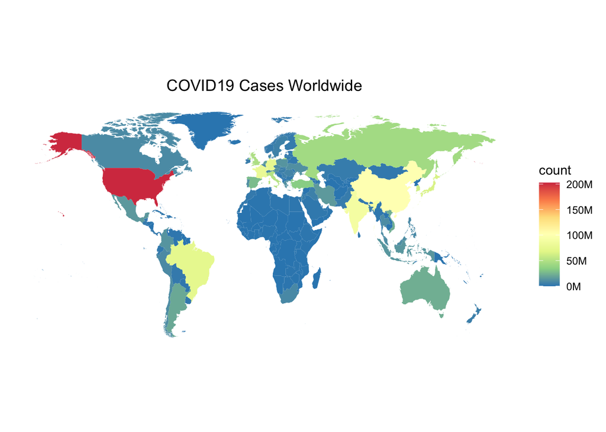

```r
world_plot_owid_who <- ggplot(data = data_owid_who, mapping = aes(x = long, y = lat, group = group)) +
  coord_fixed(1.3) +
  geom_polygon(aes(fill = count)) +
  ggtitle("COVID19 Cases Worldwide") +
  plain +
  aesthetics
world_plot_owid_who
```

#### Analyzing the difference

```r
country_wise_owid_who_cases$diff <- ((country_wise_owid_who_cases$count.y - country_wise_owid_who_cases$count.x)*100)/country_wise_owid_who_cases$count.x
country_wise_owid_who_cases[which(country_wise_owid_who_cases$diff <= -200 | country_wise_owid_who_cases$diff >= 200 & country_wise_owid_who_cases$diff != Inf), ]
```

```
##    region count.x  count.y     count     diff
## 43  China 2023378 98328848 100352226 4759.638
```

Here are the two noticeable differences:

1. The scale in the legend of the second plot is doubled.  
   This difference is expected as the WHO data we used was almost the same size as the OWID data. So, upon combining, all numbers are expected to double.
2. Numbers in China vary by a lot.  
   This discrepancy is probably because of the fact that OWID data categorizes only Mainline China as “China”, while it’s not the case with WHO data. WHO data includes numbers from Taiwan, Hong Kong, and other areas too which are not categorized under the term “Mainland China.